# Pipeline Masterarbeit

Steffen Ernst

2023-03-20

Zu beachten:

correct bezieht sich nur auf die richtige Entscheidung und nicht darauf, ob Punkte erzielt wurden.

```r
#Vorverarbeitung
#Abtrennen von Tutorialbereich


levels(df$difficulty_f) <-
  c("sehr schwer", "eher schwer", "eher leicht", "sehr leicht")
levels(df$geschlecht) <- c("männlich", "weiblich")

df_tut <- df %>%
  filter(tutorial == 1)
df <- df %>%
  filter(tutorial == 0)
#sachen die ich nachschauen möchte
#blau vs orange
```

```r
# ohne Pretest
df %>%
  filter(subject_nr > 4) %>%#nur Leute nach dem Pretest
  group_by(code) %>%
  summarise(Punkte = max(punkte1)) %>%
  arrange(desc(Punkte)) %>%
  head(n=3)
```

```
## # A tibble: 3 × 2
##   code     Punkte
##   <chr>     <dbl>
## 1 ka1996he   2520
## 2 ta1999ma   2340
## 3 an1999ma   2265
```

```r
#1. kal1996he 2520
#2. ta1999ma  2340
#3. an1999ma  2264

#mit Pretest
df %>%
 # filter(subject_nr > 4) %>%#nur Leute nach dem Pretest
  group_by(code) %>%
  summarise(Punkte = max(punkte1)) %>%
  arrange(desc(Punkte)) %>%
  head(n=3)
```

```
## # A tibble: 3 × 2
##   code     Punkte
##   <chr>     <dbl>
## 1 ka1996he   2520
## 2 ta1999ma   2340
## 3 ka2000mo   2280
```

```r
#3. ka2000mo  2280 (ausm Pretest)
```

Hier Infos zur Demographie. Zur Händigkeit: 3 ist rechtshänder, 1 ist linkshänder. In der Tabelle ist der Mean aus 4 Fragen.

```r
demographie <- df %>%
  group_by(code) %>%
  summarise(
    Alter=unique(alter),
    Gender= ifelse(unique((geschlecht))==1,"weiblich", "männlich"),
    Studiengang=unique(studiengang),
    Bildungsabschluss=if_else(unique(bildungsabschluss) == 5, "Abitur oder Fachhochschulreife", "Hochschulabschluss"),
    Händigkeit = unique(haendig_mean)
    )
kable(demographie, format = "markdown", digits = 2, align = "c")
```

| code | Alter | Gender | Studiengang | Bildungsabschluss | Händigkeit |
| --- | --- | --- | --- | --- | --- |
| an1999ma | 23 | weiblich | Physik | Abitur oder Fachhochschulreife | 3.00 |
| an2000he | 22 | männlich | Lehramt Primarstufe | Abitur oder Fachhochschulreife | 3.00 |
| ba1999wi | 23 | männlich | Medizin | Abitur oder Fachhochschulreife | 3.00 |
| bi1999ma | 23 | weiblich | Humanmedizin | Abitur oder Fachhochschulreife | 3.00 |
| es2000he | 22 | weiblich | geographie | Abitur oder Fachhochschulreife | 3.00 |
| ga1999ma | 23 | weiblich | Europäische Kunstgeschichte | Abitur oder Fachhochschulreife | 2.75 |
| ju1996be | 26 | männlich | Data and Computer Science | Hochschulabschluss | 3.00 |
| ka1996he | 26 | weiblich | Geographie | Hochschulabschluss | 3.00 |
| ka2000mo | 22 | männlich | Bildung im Primarbereich | Abitur oder Fachhochschulreife | 3.00 |
| li1999no | 23 | weiblich | Germanistik | Abitur oder Fachhochschulreife | 3.00 |
| mo1999tu | 23 | männlich | Computer Science | Hochschulabschluss | 1.00 |
| si2001fr | 22 | weiblich | Psychologie | Abitur oder Fachhochschulreife | 3.00 |
| ta1999ma | 23 | weiblich | Physik | Hochschulabschluss | 3.00 |
| ut2000we | 23 | weiblich | Germanistik und Romanistik mit Lehramtsoption | Abitur oder Fachhochschulreife | 3.00 |

Hier sind checks, ob die einzelnen Schwierigkeiten und Farben richtig balanciert sind. Sieht alles gut aus.

```r
table(df$correct_colour)
```

```
##
##    b    o
## 5376 5376
```

```r
#blau vs orange pro Schwierigkeit
df %>%
  group_by(difficulty,block) %>%
  summarise(blau = sum(str_count(correct_colour,"b")),orange = sum(str_count(correct_colour,"o")))
```

```
## # A tibble: 8 × 4
## # Groups:   difficulty [4]
##   difficulty block     blau orange
##        <dbl> <chr>    <int>  <int>
## 1          0 accuracy   672    672
## 2          0 speed      672    672
## 3          1 accuracy   672    672
## 4          1 speed      672    672
## 5          2 accuracy   672    672
## 6          2 speed      672    672
## 7          3 accuracy   672    672
## 8          3 speed      672    672
```

```r
#Schwierigkeit pro Bedingung
df %>%
  group_by(block) %>%
  summarise(s0 =sum(difficulty==0),s1 = sum(difficulty==1),s3 = sum(difficulty==2),s4 = sum(difficulty==3))
```

```
## # A tibble: 2 × 5
##   block       s0    s1    s3    s4
##   <chr>    <int> <int> <int> <int>
## 1 accuracy  1344  1344  1344  1344
## 2 speed     1344  1344  1344  1344
```

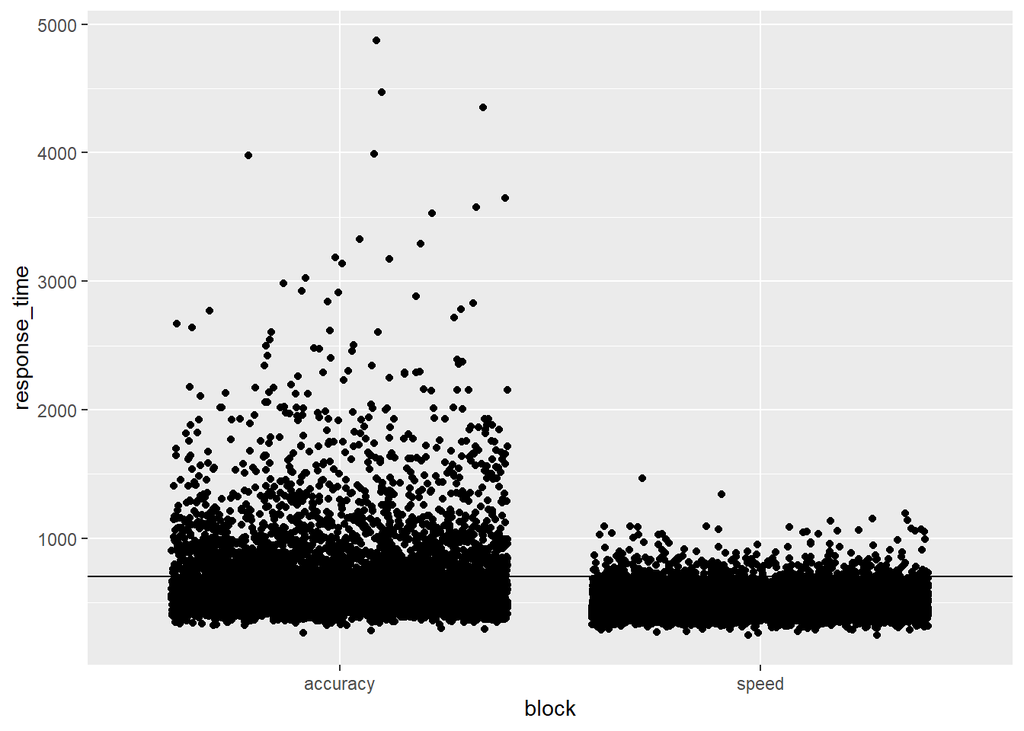

```r
ggplot(data = df, aes(x=block, y = response_time)) +
  geom_jitter() +
  geom_hline(yintercept = 700)
```

Hier mal die RTs aufgesplittet nach Person in der Speedbedingung:

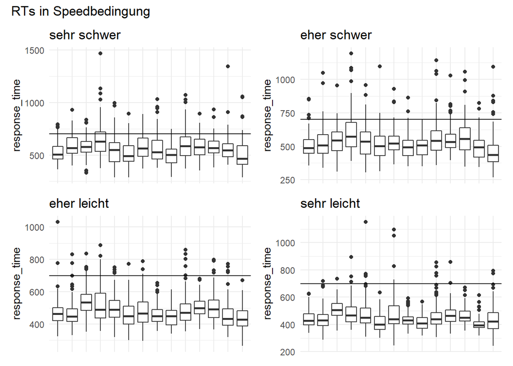

```r
list_rts_speed <- list()
j = 1
for (i in levels(df$difficulty_f)) {

  list_rts_speed[[j]] <- df %>%
  filter(difficulty_f == i, block == "speed") %>%
  ggplot(aes(x = code, y=response_time )) +
  geom_boxplot(show.legend = F) +
  theme_minimal() +
  ggtitle(i) +
 # theme(axis.text.y = element_blank()) +
  xlab("") +
  geom_hline(yintercept = unique(df$cutoff)) +
  theme(axis.title.x = element_blank(),
        axis.text.x =  element_blank(),
        axis.ticks.x = element_blank())

  j = j+1
}
(list_rts_speed[[1]] + list_rts_speed[[2]] +  list_rts_speed[[3]] + list_rts_speed[[4]]) + plot_annotation(
  title = "RTs in Speedbedingung") #subtitle = "rot = falsch, blau = richtig")
```

Und hier für die Genauigkeitsbedingung:

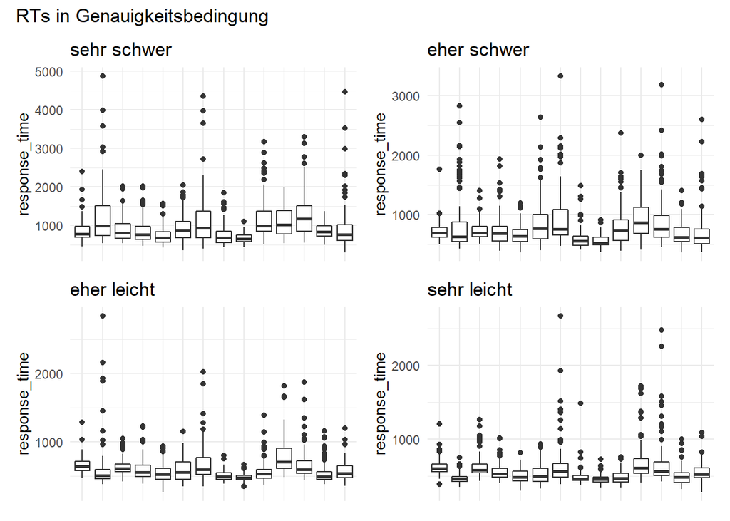

```r
list_rts_acc <- list()
j = 1
for (i in levels(df$difficulty_f)) {

  list_rts_acc[[j]] <- df %>%
  filter(difficulty_f == i, block == "accuracy") %>%
  ggplot(aes(x = code, y=response_time )) +
  geom_boxplot(show.legend = F) +
  scale_color_brewer(palette = "Reds") +
  theme_minimal() +
  ggtitle(i) +
 # theme(axis.text.y = element_blank()) +
  xlab("") +
  theme(axis.title.x = element_blank(),
        axis.text.x =  element_blank(),
        axis.ticks.x = element_blank())

  j = j+1
}
(list_rts_acc[[1]] + list_rts_acc[[2]] +  list_rts_acc[[3]] + list_rts_acc[[4]]) + plot_annotation(
  title = "RTs in Genauigkeitsbedingung")
```

Hier die RTs in der Speedbedingung pro Person:

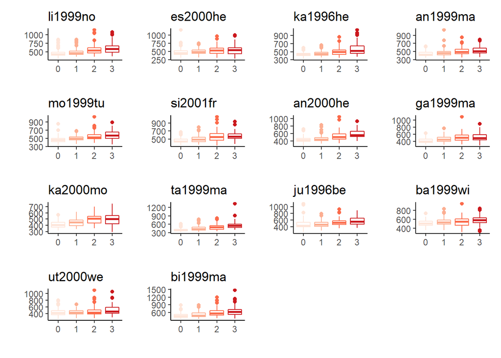

```r
list_rts_pers_speed <- list()
j = 1
for (i in unique(df$code)) {

  list_rts_pers_speed[[j]] <- df %>%
  filter(code == i, block == "speed") %>%
  ggplot(aes(x=difficulty, y = response_time, colour = as.factor(difficulty))) +
  geom_boxplot(show.legend = F) +
  scale_color_brewer(palette = "Reds") +
  theme_classic() +
  labs(colour = "Schwieirgkeit") +
  ggtitle(i) +
 # theme(axis.text.y = element_blank()) +
  xlab("") +
  ylab("")
  j = j+1
}
patchwork::wrap_plots(list_rts_pers_speed, title = "RTs in SPeedbedingung")
```

und hier in der Genauigkeitsbedingung:

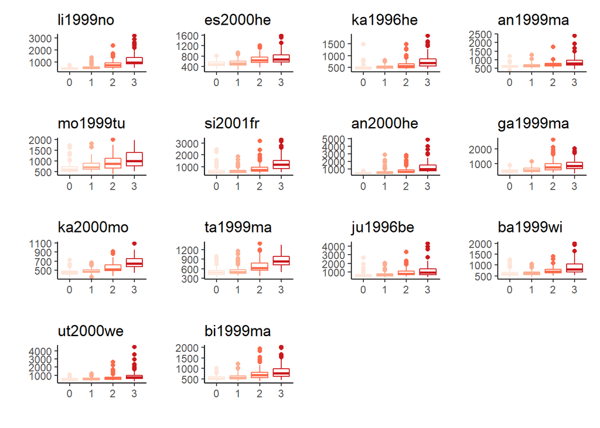

```r
list_rts_pers_acc <- list()
j = 1
for (i in unique(df$code)) {

  list_rts_pers_acc[[j]] <- df %>%
  filter(code == i, block == "accuracy") %>%
  ggplot(aes(x=difficulty, y = response_time, colour = as.factor(difficulty))) +
  geom_boxplot(show.legend = F) +
  scale_color_brewer(palette = "Reds") +
  theme_classic() +
  labs(colour = "Schwieirgkeit") +
  ggtitle(i) +
 # theme(axis.text.y = element_blank()) +
  xlab("") +
  ylab("")
  j = j+1
}
patchwork::wrap_plots(list_rts_pers_acc,  title = "RTs in Genauigkeitsbedingung")
```

Hier die richtig vs. falschen Accuracywerte als Graph:

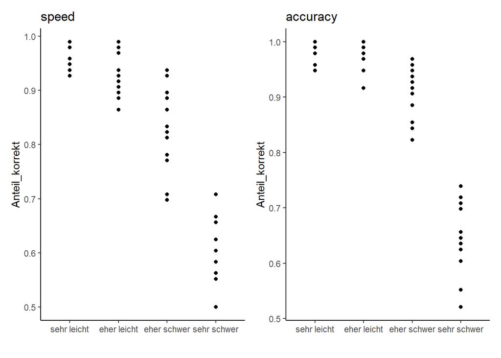

```r
results_block <- df %>%
  count(difficulty_f, block, code, correct) %>%
 # mutate(difficulty_f = fct_relevel(difficulty_f, rev(levels(difficulty_f)))) %>%
  group_by(difficulty_f, block, code) %>%
  mutate(Anteil_korrekt = n / 96) %>%
  arrange(block) %>%
  filter(correct == 1) %>%
  select(-n,-correct)

results_block$difficulty_f <- factor(
  results_block$difficulty_f,
  levels = c("sehr leicht", "eher leicht", "eher schwer", "sehr schwer")
)

j=1
list_results_all = list()
for (i in unique(df$block)) {
  list_results_all[[j]] <- results_block %>%
  filter(block == i) %>%
  arrange(Anteil_korrekt) %>%    # First sort by val. This sort the dataframe but NOT the factor levels
  #mutate(difficulty_f=factor(difficulty_f, levels=difficulty_f)) %>%
    #mutate(dificulty_f = fct_relevel(difficulty_f, "sehr schwer", "eher schwer", "eher leicht", "sehr leicht")) %>%
  ggplot(aes(x=difficulty_f, y = Anteil_korrekt)) +
  geom_point(show.legend = F)+
    scale_color_brewer(palette = "Reds") +
  theme_classic() +
  ggtitle(i) +
 # theme(axis.text.y = element_blank()) +
  xlab("")
  j = j+1
}
patchwork::wrap_plots(list_results_all)
```

eine Tabelle pro Person, pro Schwierigkeit und Phase als Tabelle:

```r
results_acc_tabelle <- results_block %>%
    #filter(block == "accuracy") %>%
    pivot_wider(names_from = code, values_from = c(Anteil_korrekt)) %>%
    rename(difficulty = difficulty_f) %>%
    mutate(difficulty = factor(difficulty, levels = c("sehr leicht", "eher leicht", "eher schwer", "sehr schwer"))) %>%
    arrange(block,difficulty)

#colnames(results_acc_tabelle) <- c("difficulty", lapply(unique(df$code), function(x) paste0("speed_", x)),lapply(unique(df$code), function(x) paste0("acc_", x)) )

 # c("difficulty", "acc_an2000he", "acc_ga1999ma", "acc_ka2000mo", "acc_li1999no", "speed_an2000he", "speed_ga1999ma", "speed_ka2000mo", "speed_li1999no")


kable(results_acc_tabelle, format = "markdown", digits = 2, align = "c")
```

| difficulty | block | an1999ma | an2000he | ba1999wi | bi1999ma | es2000he | ga1999ma | ju1996be | ka1996he | ka2000mo | li1999no | mo1999tu | si2001fr | ta1999ma | ut2000we |
| --- | --- | --- | --- | --- | --- | --- | --- | --- | --- | --- | --- | --- | --- | --- | --- |
| sehr leicht | accuracy | 0.99 | 1.00 | 0.96 | 0.98 | 0.95 | 0.99 | 1.00 | 0.99 | 0.98 | 0.98 | 0.99 | 1.00 | 1.00 | 0.99 |
| eher leicht | accuracy | 1.00 | 0.97 | 0.98 | 1.00 | 0.92 | 0.95 | 0.99 | 0.99 | 0.97 | 0.95 | 1.00 | 0.97 | 0.99 | 0.99 |
| eher schwer | accuracy | 0.93 | 0.97 | 0.85 | 0.92 | 0.84 | 0.82 | 0.91 | 0.95 | 0.93 | 0.92 | 0.89 | 0.94 | 0.91 | 0.96 |
| sehr schwer | accuracy | 0.70 | 0.62 | 0.55 | 0.65 | 0.52 | 0.71 | 0.60 | 0.74 | 0.72 | 0.62 | 0.65 | 0.65 | 0.64 | 0.66 |
| sehr leicht | speed | 0.99 | 0.99 | 0.93 | 0.96 | 0.94 | 0.98 | 0.93 | 0.99 | 0.98 | 0.94 | 0.96 | 0.99 | 0.99 | 0.95 |
| eher leicht | speed | 0.98 | 0.98 | 0.86 | 0.92 | 0.90 | 0.93 | 0.94 | 0.99 | 0.94 | 0.91 | 0.97 | 0.99 | 0.97 | 0.89 |
| eher schwer | speed | 0.89 | 0.90 | 0.71 | 0.90 | 0.70 | 0.81 | 0.83 | 0.94 | 0.86 | 0.77 | 0.82 | 0.78 | 0.93 | 0.77 |
| sehr schwer | speed | 0.58 | 0.62 | 0.56 | 0.66 | 0.67 | 0.62 | 0.58 | 0.60 | 0.55 | 0.50 | 0.71 | 0.58 | 0.67 | 0.55 |

!!! Die nachfolgenden Plots gehen über ALLE Datenpunkte hinweg, da weiß ich nicht ob die so sinnvoll sind. !!! DIe einzelnen Plots finden sich in den Reports subject 1-4.

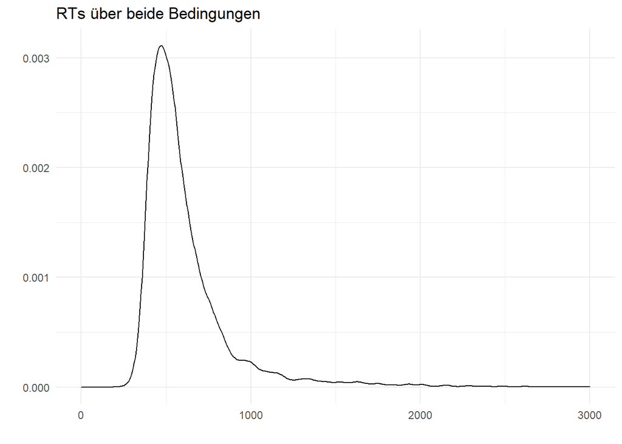

```r
df %>%
  ggplot(aes(x=response_time, colour = correct)) +
  geom_density() +
  theme_minimal() +
  ggtitle("RTs über beide Bedingungen")+
  ylab("") +
  xlim(0,3000) +
  xlab("")
```

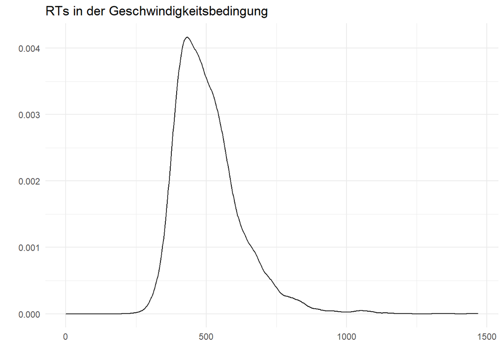

```r
df %>%
  filter(block == "speed") %>%
  ggplot(aes(x=response_time, colour = correct)) +
  geom_density() +
  theme_minimal() +
  ggtitle("RTs in der Geschwindigkeitsbedingung")+
  ylab("") +
  xlim(0,max(df[df$block == "speed",]$response_time)) +
  xlab("")
```

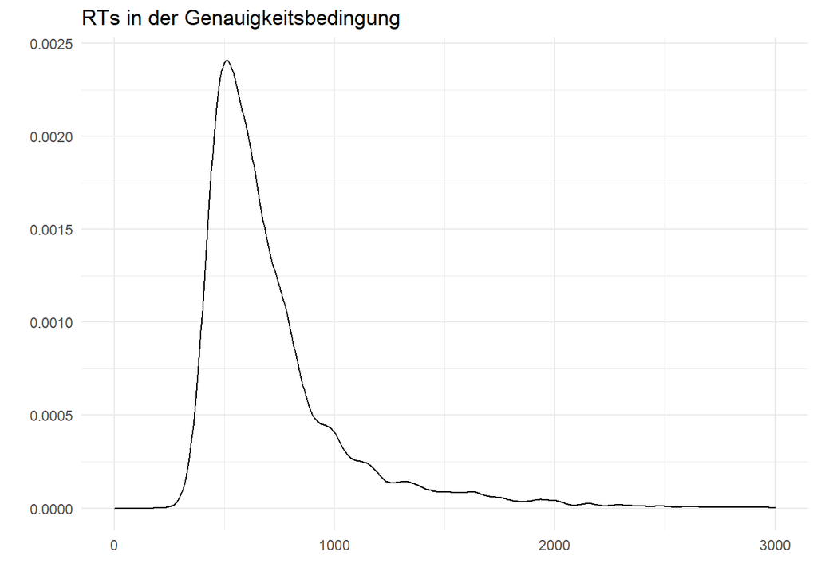

```r
df %>%
  filter(block == "accuracy") %>%
  ggplot(aes(x=response_time, colour = correct)) +
  geom_density() +
  theme_minimal() +
  ggtitle("RTs in der Genauigkeitsbedingung")+
  ylab("") +
  xlim(0,3000) +
  xlab("")
```

Hier die RTs je nach Schwierigkeit in der Speedbedingung:

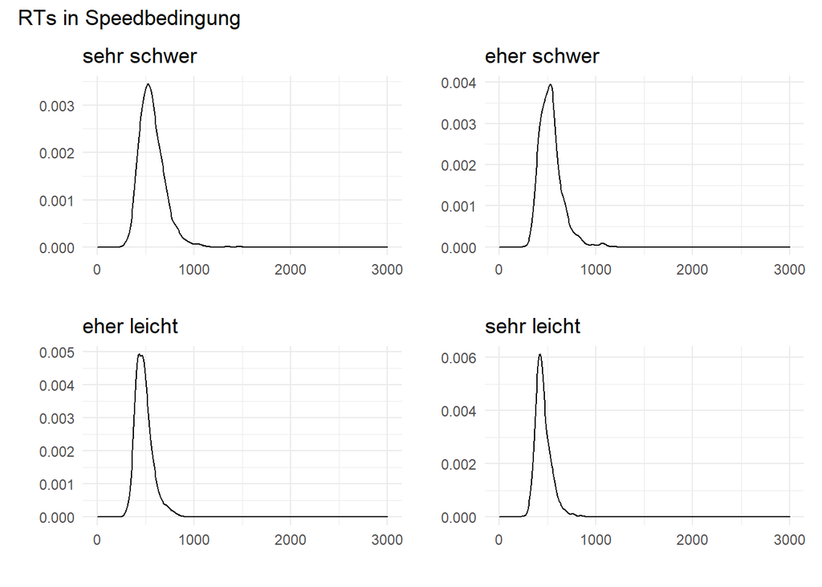

```r
list_speed <- list()
j = 1
for (i in levels(df$difficulty_f)) {
  list_speed[[j]] <- df %>%
   filter(block == "speed", difficulty_f == i) %>%
  ggplot(aes(x=response_time, colour = correct)) +
  geom_density(adjust = 1.1) +
  theme_minimal() +
  ggtitle(i) +
 # theme(axis.text.y = element_blank()) +
  ylab("") +
  xlim(0,3000) +
  xlab("")

  j = j+1
}
(list_speed[[1]] + list_speed[[2]] +  list_speed[[3]] + list_speed[[4]]) + plot_annotation(
  title = "RTs in Speedbedingung") #subtitle = "rot = falsch, blau = richtig")
```

Hier die RTs je nach Schwierigkeit in der Genauigkeitsbedingung:

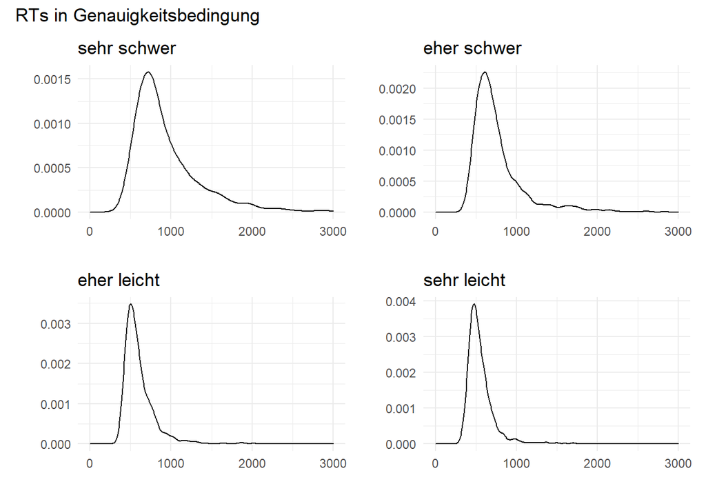

```r
list_acc <- list()
j = 1
for (i in levels(df$difficulty_f)) {
  list_acc[[j]] <- df %>%
   filter(block == "accuracy", difficulty_f == i) %>%
  ggplot(aes(x=response_time, colour = correct)) +
  geom_density(adjust = 1.1) +
  theme_minimal() +
  ggtitle(i) +
 # theme(axis.text.y = element_blank()) +
  ylab("") +
  xlim(0,3000) +
  xlab("")

  j = j+1
}
(list_acc[[1]] + list_acc[[2]] +  list_acc[[3]] + list_acc[[4]]) + plot_annotation(
  title = "RTs in Genauigkeitsbedingung") #subtitle = "rot = falsch, blau = richtig")
```

Hier noch ein neuer Plot für die Farben-Präferenz

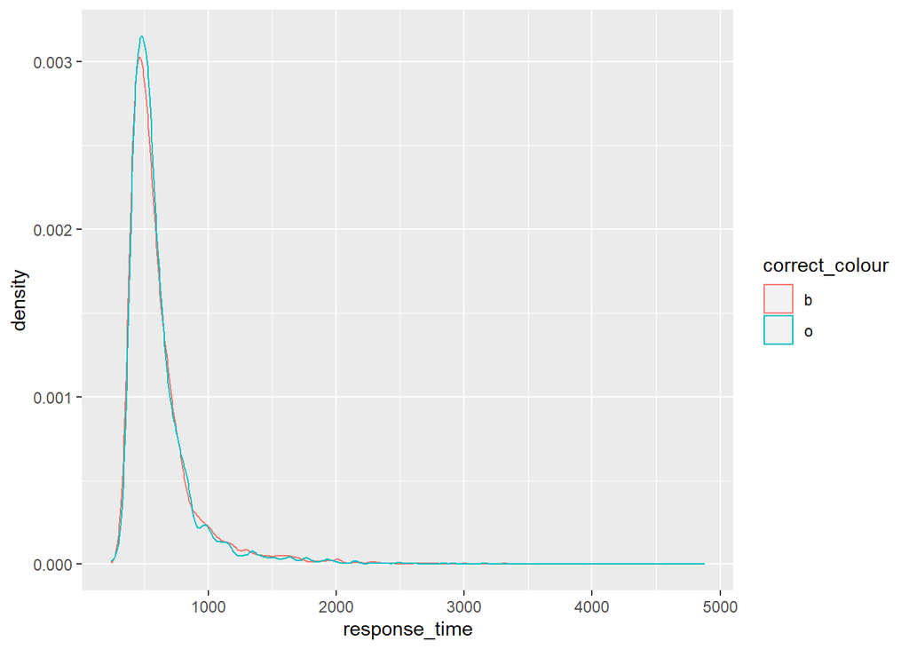

```r
df %>%
  ggplot(aes(x=response_time, colour = correct_colour)) +
  geom_density()
```

Hier sind noch mehr weniger nützliche Plots:

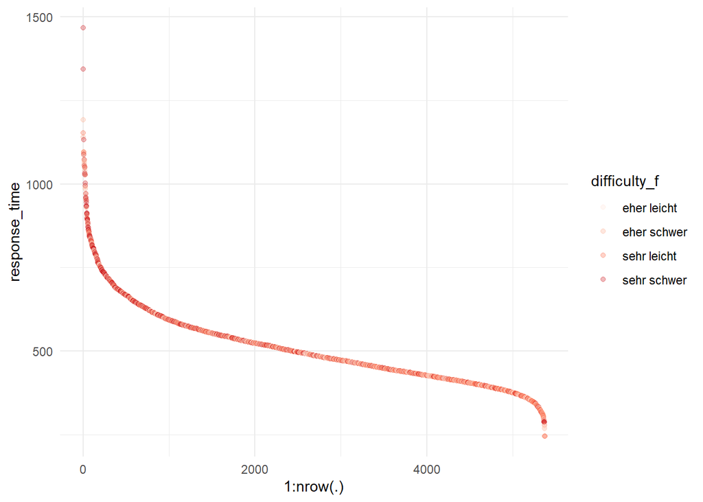

```r
df_arranged <- df %>%
  group_by(block) %>%
  arrange(., desc(response_time))

df_arranged %>%
filter(block == "speed") %>%
      ggplot(., aes(x=1:nrow(.), y=response_time, colour = difficulty_f)) +
  geom_point(alpha = .3) + #,subset(df_arranged,block != "accuracy")) +
  scale_color_brewer(palette = "Reds") +
  theme_minimal()
```

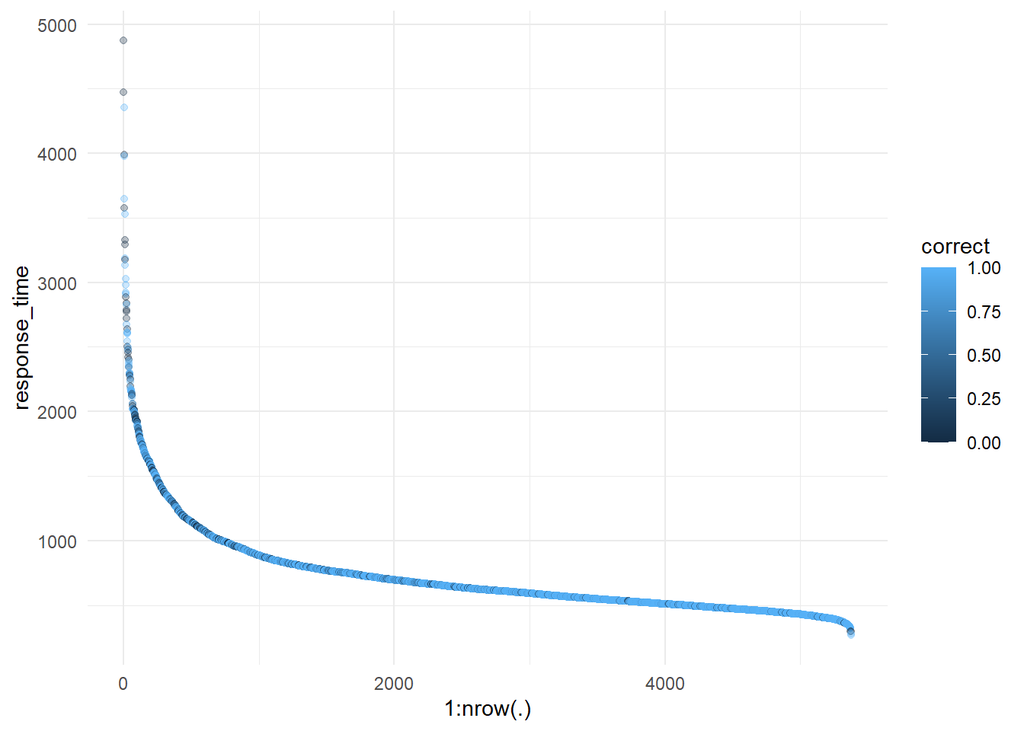

```r
df_arranged %>%
filter(block == "accuracy") %>%
      ggplot(., aes(x=1:nrow(.), y=response_time, colour = correct)) +
  geom_point(alpha = .3) + #,subset(df_arranged,block != "accuracy")) +
  theme_minimal()
```